# qualtricsr

## Overview

The `quiltr` package is designed for generating Qualtrics importable forms for data labelling, in particular text labelling.

There are two workhorse functions, which are `quilt_form_data()` and `quilt_form`. The first of these takes a dataset of text for labelling and structures it appropriately for writing the Qualtrics data labelling form. The second takes the `data.frame` produced by `quilt_form_data()` and generates a .txt file that is importable into Qualtrics.

In the package are several bundled datasets, which are useful for testing and understanding how the package functions. These are named: `lipsum_text`, `arabiya_text`, and `qdat`.

| Dataset | Description |
| --- | --- |
| lipsum_text | Dataset of (pseudo) random lipsum text generated using the `stringi` package |
| arabiya_text | Dataset of Arabic text data sampled from https://data.mendeley.com/datasets/57zpx667y9/2 |
| qdat | Dataset containing one hundred paragraphs of lipsum text with columns for text (prompt), response_type and ID as generated by `quilt_form_data` |

We first load one of these datasets into memory:

```r
data(lipsum_text)
```

We can then call `quilt_form_data()`, which takes the following arguments:

```r
qdat <- quilt_form_data(prompt = "Label this text: ",
                     text = lipsum_text$text, response_type = "scale",
                     nlow = 1, nhigh = 10, addID = T)
```

The `prompt` argument is optional and gives the user the ability to add a prompt before the text for labelling. The second argument is the text to be labelled. Here, we are specifying our dummy `lipsum_text` data and, specifically, the column `lipsum_text$text`. The `response_type` parameter has several options, including “scale” for an integer scale. For this, we then need to specify an upper and lower bound with the `nlow` and `nhigh` parameters. The other options here are “yesno” for a binary yes or no response, and “options,” which then requires the additional `options` parameter.

Once we have our data in the appropriate format, we can then generate our Qualtrics importable form with `quilt_form()` as follows:

```r
quilt_form(input_data = qdat,
            page_break_every = 1, question_type = "multianswer",
            filename = "quilted_survey.txt")
```

## Importing to Qualtrics

After we’ve generated the file in the appropriate format, we can import to Qualtrics. First we go to the survey in question, here named “import_test.” We then click on tools and select the “Import/Export” > “Import survey.”

[figure not shown]

Qualtrics will then prompt us to select the relevant .txt file, which we previously generated with `quilt_form`. We select here “quilted_survey.txt” and press “Import.” We have now successfully imported our survey into Qualtrics!

[figure not shown]

## Question types

There are several options for question types for text labelling tasks. The first group allow the user to select from a set of options (e.g., “Yes/No/Maybe”), and allow respondents to select either one or multiple answers depending on whether we specify e.g., “select” or “multiselect” as our `question_type` argument.

The table below details the different question types, and how they are rendered in Qualtrics.

`question_type`

Description

Example

“dropdown”

Dropdown select box

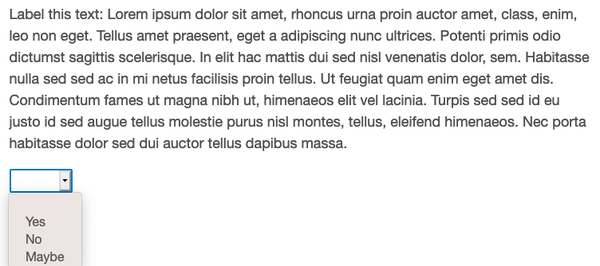

“select”

Vertical list select

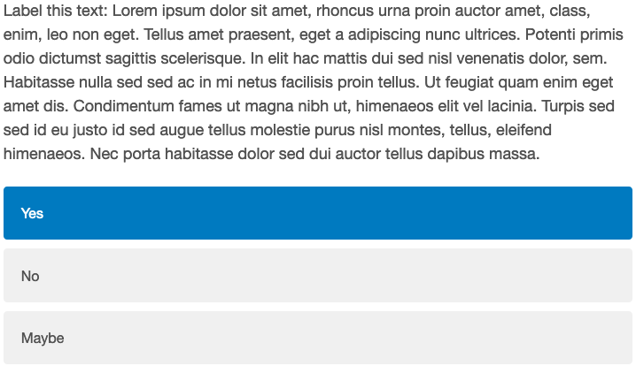

“multiselect”

Vertical list multiselect

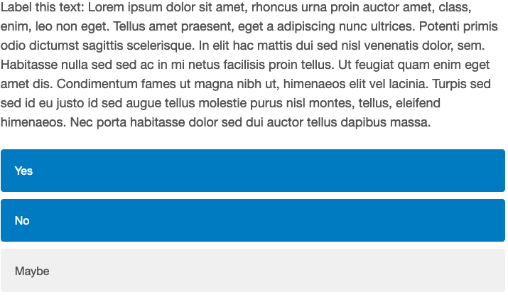

“singleanswer”

Horizontal list select

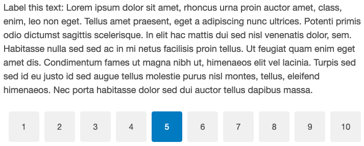

“multianswer”

Horizontal list multiselect

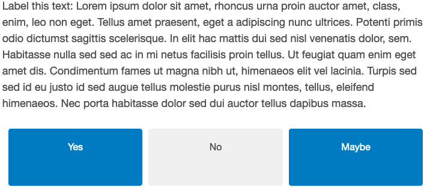

“rankorder”

Vertical list of draggable ranked options

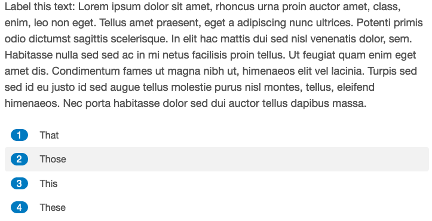

“singleline”

Single line text entry

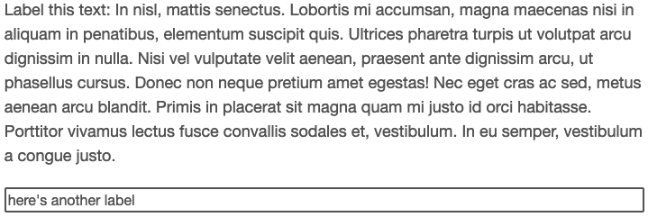

“essay”

Multiline text entry

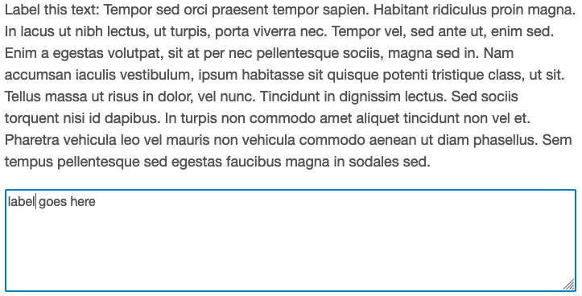

## Non-Latin language support

The package works equally well with Latin languages as it does with non-Latin languages, including languages written from right-left such as Arabic. We can see this below where we use a mixture of Arabic text and English prompts.

```r
qdat <- quilt_form_data(prompt = "Label this text: ",
                     text = arabiya_text$text, response_type = "scale",
                     nlow = 1, nhigh = 10, addID = T)
```

```r
quilt_form(input_data = qdat,
            page_break_every = 1, question_type = "multianswer",
            filename = "quilted_survey.txt")
```

After importing into Qualtrics, we see that the prompt and Arabic text is correctly displayed:

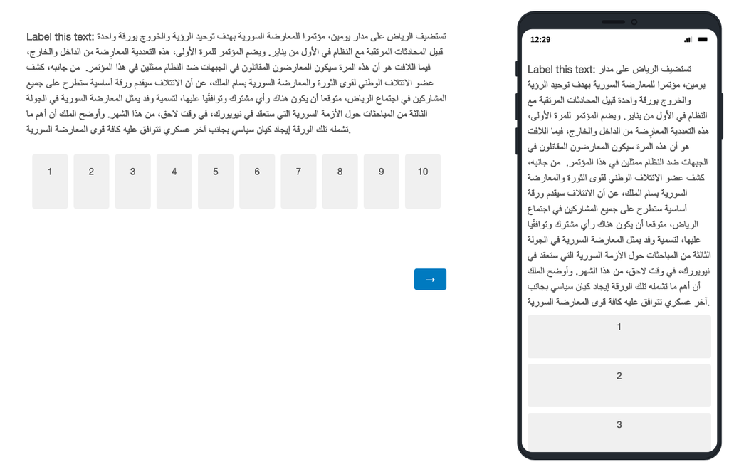